[figure not shown]

# Introduction to Simple Linear Regression

## Topics and Outcomes

- Understand Supervised Machine Learning.
- Understand what is Regression.
- Main types of linear regression models.
- Introduce the concept of Best-Fit-Line, hypothesis function, OLS method and the cost function.
- Solving simple regressoin using the Closed Form Solution.
- Introduce the Gradient Descent algorithm for solving regression.
- Introduce the assumptions for linear regression.
- Introduce the evaluation metrics for regression.
- Introduce Scikit-Learn library in Python.
- Solving simple linear regression using scitkit-learn.

## What is Supervised Learning?

Supervised machine learning is a type of learning where a model learns from labeled data. The process follows these key steps:

- Input Features (X): The model takes input data (features) which represents the information used to make predictions.
- Prediction Function: The model, with some parameters (θ), processes the input data to generate predictions (Ŷ).
- Output (Ŷ): This is the model’s prediction based on the input features.
- Cost Function: The predicted output (Ŷ) is compared to the actual labels (Y) to calculate an error or "cost."
- Optimization: The model adjusts its parameters (θ) to minimize the error, improving its predictions over time.
- This process repeats iteratively until the model achieves good accuracy. It's commonly used for tasks like classification (e.g., spam detection) and regression (e.g., predicting house prices).

[figure not shown]

## What is Regressions Analysis?

Linear regression is a type of supervised machine learning algorithm that computes the linear relationship between a dependent variable and one or more independent variables (features) by fitting a linear equation to observed data.

When there is only one independent feature, it is known as Simple Linear Regression, and when there are more than one feature, it is known as Multiple Linear Regression.

#### Why Linear Regression is Important:

1. **Interpretability**: Linear regression provides clear, interpretable coefficients that explain the relationship between independent and dependent variables.
2. **Simplicity**: It is transparent, easy to implement, and serves as a foundational concept for more complex algorithms.
3. **Basis for Advanced Models**: Many advanced techniques (e.g., regularization, support vector machines) are extensions or adaptations of linear regression.
4. **Assumption Testing**: It helps in validating key assumptions about the data, making it crucial in statistical analysis.

## Types of Linear Regression

There are two main types of linear regression:

**1- Simple Linear Regression**

This is the simplest form of linear regression, and it involves only one independent variable and one dependent variable. The equation for simple linear regression is:

$$ y = \beta_0 + \beta_1 X $$

where:

- ( $ y $ ) is the dependent variable
- ( $ X $ ) is the independent variable
- $ \beta_0 $ is the intercept
- $ \beta_1 $ is the slope

### 2- Multiple Linear Regression (Simplified)

In multiple linear regression, there is one dependent variable and more than one independent variable. The equation is:

$ y = \beta_0 + \beta_1 X_1 + \beta_2 X_2 + \dots + \beta_n X_n $

Where:

- $y$ is the dependent variable (what we want to predict)
- $X_1, X_2, \dots, X_n$ are the independent variables (inputs)
- $beta_0$ is the intercept
- $beta_1, \beta_2, \dots, \beta_n$ are the slopes (coefficients)

The goal is to find the **best-fit line** that predicts $y$ based on the independent variables $X_1, X_2, \dots, X_n$.

This learned function can then be used to predict $y$ for new $X$ values. The function predicts continuous outcomes based on the input features.

### What is the Best Fit Line?

[figure not shown]

In linear regression, the **best-fit line** is the line that minimizes the error between the predicted and actual values. It represents the relationship between the dependent and independent variables.

[figure not shown]

The slope of the line shows how much the dependent variable changes for each unit change in the independent variable(s). The goal is to find this line to make the most accurate predictions.

### Finding the Best Fit Line Using The OLS Method:

- The Ordinary Least Squares (OLS) method is a fundamental approach in Linear Regression (LR) used to estimate the relationship between independent variables (X) and a dependent variable (Y).
- OLS minimizes the sum of the squared differences (Cost Function) between the observed values and the predicted values from the regression line, ensuring the best possible fit.
- The **Mean Squared Error (MSE)** is a cost function that we use to measure the error between the predicted $ \hat{Y} $ and the actual $ Y $, and it is the function that OLS tries to minimize.

$ J = \frac{1}{n} \sum_{i=1}^{n} (\hat{y}_i - y_i)^2 $

[figure not shown]

### Solving Linear Regression with the Closed-Form Solution

[figure not shown]

The closed-form solution for Simple Linear Regression (SLR) is a direct mathematical formula used to compute the slope (𝛽1) and intercept (𝛽0) of the best-fit line without iterative optimization.

1. **Slope ($\beta_1$)** is given by:

$$ \beta_1 = \frac{\text{Cov}(X, y)}{\text{Var}(X)} $$

Where:

- $\text{Cov}(X, y)$ is the covariance between $X$ and $y$,
- $\text{Var}(X)$ is the variance of $X$.
2. **Intercept ($\beta_0$)** is calculated as:

$$ \beta_0 = \bar{y} - \beta_1 \bar{X} $$

Where:

- $\bar{y}$ is the mean of the dependent variable $y$,
- $\bar{X}$ is the mean of the independent variable $X$.

### Python Code to Compute the Coefficients Using This Method

Below is the Python code that computes the slope and intercept using the covariance-variance method.

```python
import numpy as np
import pandas as pd

# Data: YearsExperience and Salary
data = {
    "YearsExperience": [1.1, 1.3, 1.5, 2.0, 2.2, 2.9, 3.0, 3.2, 3.2, 3.7, 3.9, 4.0, 4.0, 4.1, 4.5, 4.9, 5.1, 5.3, 5.9, 6.0, 6.8, 7.1, 7.9, 8.2, 8.7, 9.0, 9.5, 9.6, 10.3, 10.5],
    "Salary": [39343, 46205, 37731, 43525, 39891, 56642, 60150, 54445, 64445, 57189, 63218, 55794, 56957, 57081, 61111, 67938, 66029, 83088, 81363, 93940, 91738, 98273, 101302, 113812, 109431, 105582, 116969, 112635, 122391, 121872]
}

# Create a pandas DataFrame
df = pd.DataFrame(data)

# Extract the independent (X) and dependent (y) variables
X = df["YearsExperience"]
y = df["Salary"]

# Calculate the means of X and y
X_mean = np.mean(X)
y_mean = np.mean(y)

# Calculate the covariance of X and y and the variance of X
cov_X_y = np.sum((X - X_mean) * (y - y_mean))  # Covariance
var_X = np.sum((X - X_mean) ** 2)              # Variance

# Calculate the slope (beta_1) and intercept (beta_0)
slope = cov_X_y / var_X
intercept = y_mean - slope * X_mean

# Print the slope and intercept
print(f"Slope (beta_1): {round(slope,2)}")
print(f"Intercept (beta_0): {round(intercept,2)}")


# Using the model to predict new values
years_of_experience = 15.5
predicted_salary = slope * years_of_experience + intercept
print(f"The expected/predicted salary of the new employee is: {round(predicted_salary,2)}")
```

```
Slope (beta_1): 9449.96
Intercept (beta_0): 25792.2
The expected/predicted salary of the new employee is: 172266.62
```

The closed-form solution is efficient for small to medium-sized datasets, but it becomes computationally expensive for large datasets because it requires calculating the inverse of a matrix. It works well when:

- The dataset is not very large (typically up to thousands of rows).
- The number of features (independent variables) is small.
- There are no multicollinearity issues (i.e., features are not highly correlated).

For larger datasets or more complex models, iterative methods like **Gradient Descent** are preferred.

### Solving Linear Regression Using The Gradient Descent Method

[figure not shown]

[output not shown]

[figure not shown]

**Computing $ \beta_0 $ Rate of Change:** $$ \beta_0 = \beta_0 - \alpha \left( J'_{\beta_0} \right) $$

$$ = \beta_0 - \alpha \left( \frac{2}{n} \sum_{i=1}^{n} (\hat{y}_i - y_i) \right) $$

**Computing $ \beta_1 $ Rate of Change:** $$ \beta_1 = \beta_1 - \alpha \left( J'_{\beta_1} \right) $$

$$ = \beta_1 - \alpha \left( \frac{2}{n} \sum_{i=1}^{n} (\hat{y}_i - y_i) \cdot x_i \right) $$

## Evaluation Metrics for Linear Regression

[figure not shown]

A variety of evaluation measures can be used to determine the strength of any linear regression model. These assessment metrics often give an indication of how well the model is producing the observed outputs.

The most common measurements are:

1. **Mean Squared Error (MSE)**  
   Measures the average squared difference between actual and predicted values:

   $$ MSE = \frac{1}{n} \sum_{i=1}^{n} \left( y_i^{\text{actual}} - y_i^{\text{predicted}} \right)^2 $$
2. **Root Mean Squared Error (RMSE)**  
   The square root of MSE, providing the error in the same units as the target variable:

   $$ RMSE = \sqrt{\frac{1}{n} \sum_{i=1}^{n} \left( y_i^{\text{actual}} - y_i^{\text{predicted}} \right)^2} $$
3. **R-squared (Coefficient of Determination)**  
   The proportion of variance in the dependent variable explained by the independent variables:

   $$ R^2 = 1 - \frac{SS_{\text{residual}}}{SS_{\text{total}}} $$

   Where:

   $$ SS_{\text{residual}} = \sum_{i=1}^{n} \left( y_i^{\text{actual}} - y_i^{\text{predicted}} \right)^2 $$

   $$ SS_{\text{total}} = \sum_{i=1}^{n} \left( y_i^{\text{actual}} - \bar{y} \right)^2 $$
4. **Adjusted $ R^2 $**  
   Adjusted $ R^2 $ modifies $ R^2 $ to account for the number of predictors, providing a more accurate measure for models with multiple variables. Unlike $ R^2 $, which can increase simply by adding more predictors, Adjusted $ R^2 $ will only increase if the new predictors improve the model more than expected by chance:

   $$ \text{Adjusted } R^2 = 1 - \left(1 - R^2\right) \frac{n - 1}{n - p - 1} $$

In these formulas:

- $ y_i^{\text{actual}} $ represents the actual observed values,
- $ y_i^{\text{predicted}} $ represents the predicted values from the model,
- $ \bar{y} $ is the mean of the actual values,
- $ n $ is the number of data points, and
- $ p $ is the number of predictors (independent variables) in the model.

## Implementing Regression using Scikit-Learn Library in Python

#### What is scikit-learn?

[figure not shown]

scikit-learn is a very popular tool, and the most prominent Python library for machine learning. It is widely used in industry and academia, and a wealth of tutorials and code snippets are available online.

- scikit-learn is an open source project, meaning that it is free to use and distribute.
- This library, which is largely written in Python, is built upon NumPy, SciPy and Matplotlib.
- The scikit-learn project is constantly being developed and improved, and it has a very active user community.
- It contains a number of state-of-the-art machine learning algorithms, as well as comprehensive documentation about each algorithm.
- Scikit-learn provides a selection of efficient tools for machine learning and statistical modeling including classification, regression, clustering and dimensionality reduction via a **consistence interface** in Python.

[Scikit Learn](https://www.w3schools.com)

### Practical Example - Predicting Apartment Price based on its Size

[figure not shown]

In this example, we will user a dataset that has two variables: Price (dependent variable) and Square_Area (Independent variable).  
We will create a Simple Linear Regression model to find out the best fitting line for representing the relationship between these two variables.

### Process Steps:

1. Import the required Libraries
2. Import the Dataset
3. Scrub the Dataset, correct any errors in the data, make need transformations
4. Split the Dataset into training and testing datasets
5. Select a Machine Learning algorithm and configure its parameters
6. Fit/Train the Model
7. Make Predictions
8. Evaluate the results and the accuracy of the model

[figure not shown]

#### Import the required libraries and the Dataset

```python
import numpy as np
import pandas as pd
import matplotlib.pyplot as plt

# import the required machine learning libraries
from sklearn.linear_model import LinearRegression
from sklearn.model_selection import train_test_split
from sklearn.metrics import r2_score

df = pd.read_csv('https://raw.githubusercontent.com/msfasha/307304-Data-Mining/refs/heads/main/20242/datasets/apartment_prices.csv')
print(f"Number of rows in the dataset: {len(df)}")
df.head(3)
```

```
Number of rows in the dataset: 500
```

|  | Square_Area | Num_Rooms | Age_of_Building | Floor_Level | City | Price |
| --- | --- | --- | --- | --- | --- | --- |
| 0 | 162 | 1 | 15 | 12 | Amman | 74900.0 |
| 1 | 152 | 5 | 8 | 8 | Aqaba | 79720.0 |
| 2 | 74 | 3 | 2 | 8 | Irbid | 43200.0 |

#### Prepare the dataset

```python
x = df.iloc[:, 0].values.reshape(-1, 1)  # Reshape x to be a 2D array
y = df.iloc[:, -1].values  # y can remain as a 1D array

# x = df["Square_Area"]
# y= df["Price"]
```

#### Split the dataset into training and testing segments

```python
# Splitting the dataset into training and test set.
x_train, x_test, y_train, y_test= train_test_split(x, y, test_size= .1, random_state=0)
```

#### Create the Machine Learning model and make any required configurations

```python
regressor= LinearRegression()
```

#### Train the model using the training dataset

```python
regressor.fit(x_train, y_train)

print(regressor.coef_)
print(regressor.intercept_)
```

```
[362.33639889]
15802.319376714753
```

In the above code, we used the fit() method to fit\train our Simple Linear Regression model using the training set.

We passed the x_train and y_train datasets to the fit() function, which are our training datasets for the dependent and an independent variable.

#### Make Predictions

Now, our model is ready to predict the output for the new observations.

In this step, we will provide the test dataset (new observations) to the model to check whether it can predict the correct output or not.

We will create a prediction vector test_predictions, and train_predictions, which will contain predictions of the test dataset, and prediction of the training set respectively.

```python
# Make predictions using the training dataset
train_predictions= regressor.predict(x_train)
```

#### Measuring The Model Performance

##### Examine the Model using the Training Set

[figure not shown]

##### Evaluate the Model Visually

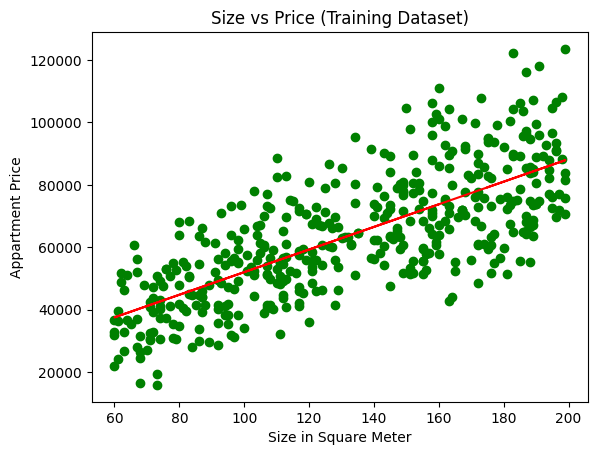

```python
# plot the training data with the original dependent variable
plt.scatter(x_train, y_train, color="green")

# plot the training data with the predictions
plt.plot(x_train, train_predictions, color="red")

plt.title("Size vs Price (Training Dataset)")
plt.xlabel("Size in Square Meter")
plt.ylabel("Appartment Price")
plt.show()
```

#### Evaluate the Model Using Numerical Measures

**Evaluating Regression Model Using R-Squared ($ R^2 $)**

**R-Squared ($ R^2 $)** is a key metric for evaluating a regression model’s performance. It measures how well the independent variable(s) explain the variability of the dependent variable.

$ R^2 = 1 - \frac{SS_{res}}{SS_{tot}} $

where:

- $ SS_{res} $ = Sum of Squared Residuals (error)
- $ SS_{tot} $ = Total Sum of Squares (variance in $ Y $)

### **Interpretation:**

- $ R^2 = 1 $ → Perfect fit (model explains all variability in $ Y $).
- $ R^2 = 0 $ → Model explains none of the variance.
- **Higher $ R^2 $ means better fit**, but it doesn’t imply causation.

```python
r2 = r2_score(y_train, train_predictions)
r2 = round(r2,2)
print("r2 score: ", r2)
```

```
r2 score:  0.54
```

##### Manual computation of r-sqaured value

```python
# sum of squared explained / sum of sqaured total
explained_percentage = sum((train_predictions - y_train.mean())**2)/sum((y_train - y_train.mean())**2)
print(f"r-squared value is:", explained_percentage)

# sum of squared error / sum of sqaured total
unexplained_percentage = sum((y_train - train_predictions)**2) / sum((y_train - y_train.mean())**2)
print(f"percentage of unexplained variance:", unexplained_percentage)
```

```
r-squared value is: 0.5383585844294305
percentage of unexplained variance: 0.4616414155705701
```

#### Examining the model using the Test Dataset

In the previous step, we have visualized the performance of our model on the training set.

Now, we will do the same for the Test dataset. The complete code will remain the same as the above code, except now we will use x_test, and testing_predictions instead of x_train and y_train.

```python
# Make predictions using the test dataset
test_predictions= regressor.predict(x_test)
```

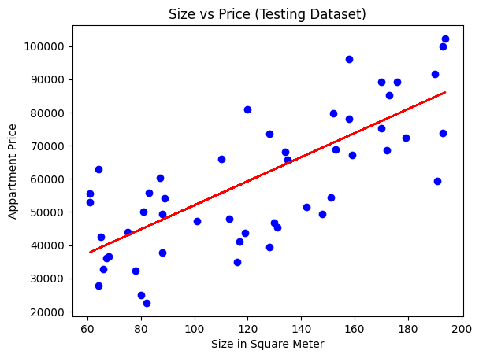

```python
# Plot the original values in the testing set (x_test and y_test)
plt.scatter(x_test, y_test, color="blue")

# Plot the x_test with the predicted test data
plt.plot(x_test, test_predictions, color="red")

plt.title("Size vs Price (Testing Dataset)")
plt.xlabel("Size in Square Meter")
plt.ylabel("Appartment Price")
plt.show()
```

But we can compute the R^2 (R-Squared) which provides us with a systematic numerical value for the accuracy of our model.

#### Evaluate the Model Using Numerical Measures

```python
from sklearn.metrics import r2_score

r2 = round(r2_score(y_test, test_predictions),2)
print("r2 score: ", r2)
```

```
r2 score:  0.55
```